# NFL Big Data Bowl 2021

## Motivation and Design

**Main Point:** Understanding how defensive strategies impact NFL play outcomes.

- **Focus:** Investigate if more defenders in the box reduce offensive yards gained.
- **Significance:**
  - Helps coaches balance between rushing and coverage plays.
  - Guides decisions on optimizing defensive play-calling.
- **Inspiration:**
  - Shared passion for football and analytics.
  - Contribute to the growing field of sports analytics.

## Methodology

- Data Preparation
  - Filtered passing plays; cleaned data to 17,330 observations. Response variable: offensive yards gained (excluding penalties). Predictors: number of defenders in the box and pass rushers. Exploratory Data Analysis (EDA):
  - Visual tools: boxplots, heatmaps, correlation matrix. Pass rushers showed slightly stronger correlation with play result (0.032) than defenders in the box (0.006).
- **Modeling:**
  - Linear Regression: Captures direct linear relationships.
  - Generalized Additive Model (GAM): Accounts for non-linear relationships with smooth terms.
  - Train-test split (80/20) and 5-fold cross-validation for performance evaluation.

## Data Quality

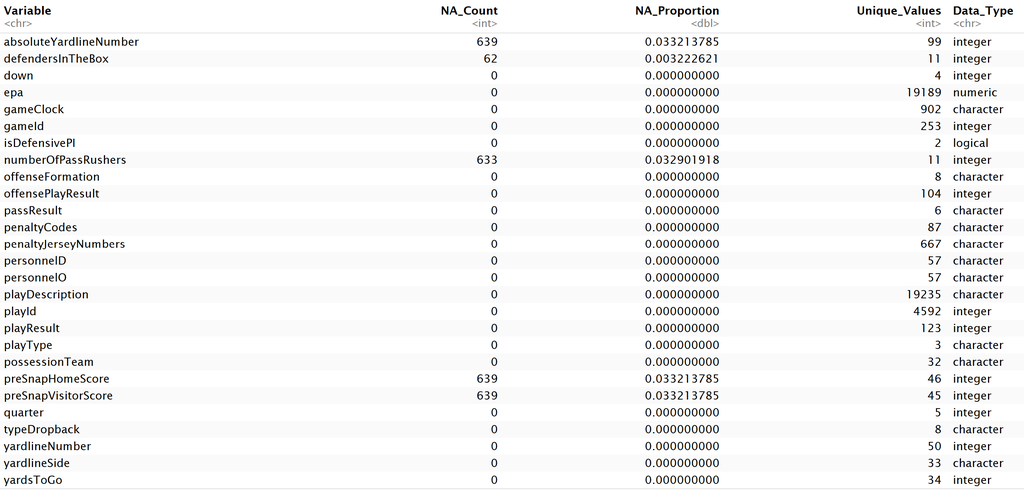

## EDA

## Individual Variables

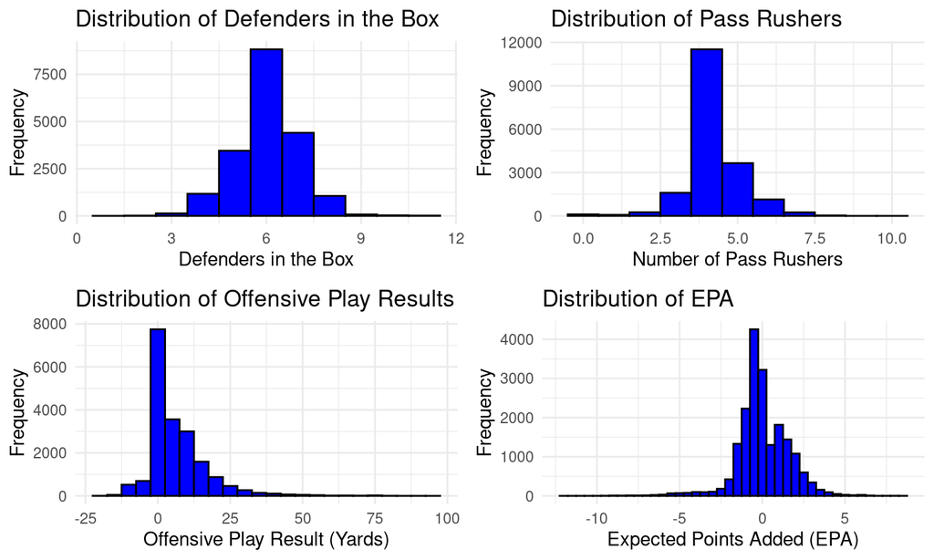

## Combinations

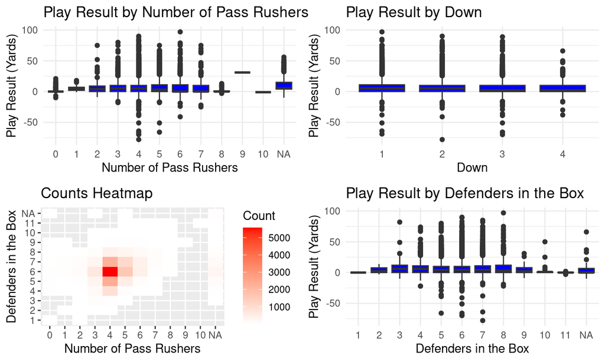

## Model Results

## Results

[output not shown]

## Gam Model

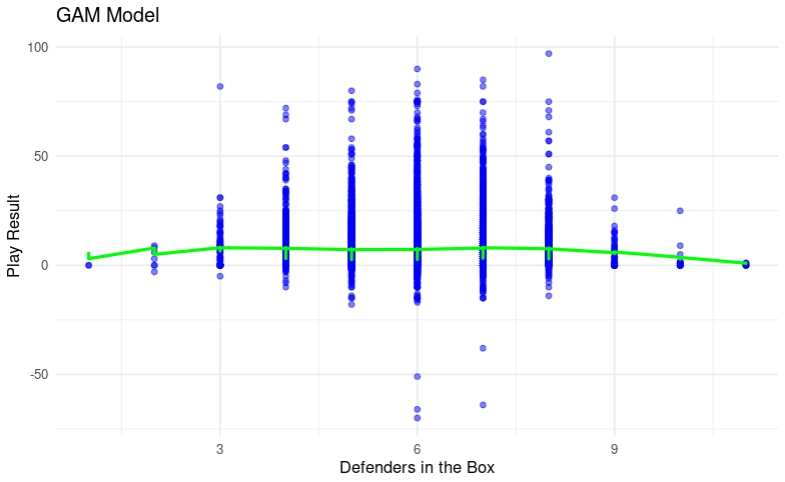

## Linear Regression Model

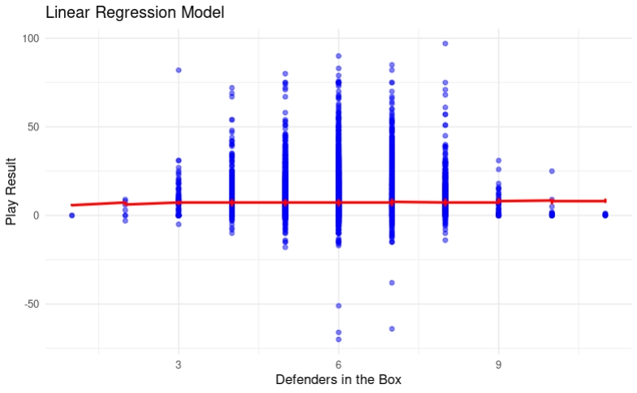

## Random Forest Results

```
- The random forest was only able to accurately predict the relationship on
playResult from defendersInTheBox and numberOfPassRushers with an accuracy
of 4.53%
- However, numberOfPassRushers had an importance score of 6791 and defenders
in the box had importance score of 4881.880
```

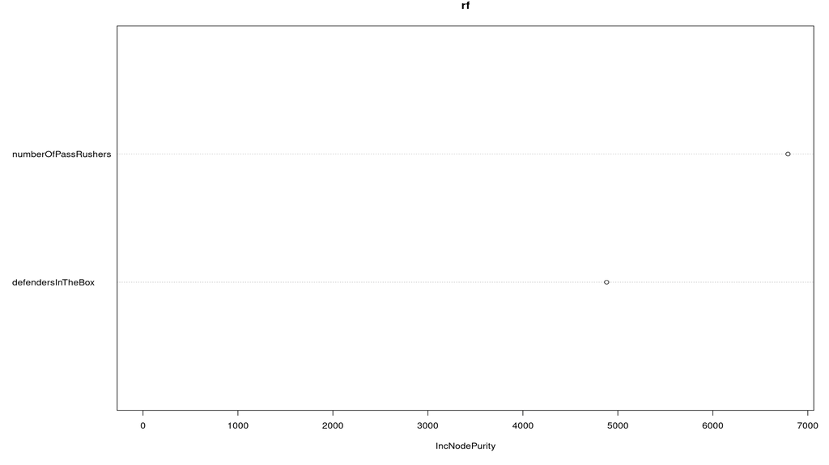

## XGBoost Results

```
-Test RMSE: 9.83
-Slight improvements could be the result of less overfitting and
presence of interactions between features
```

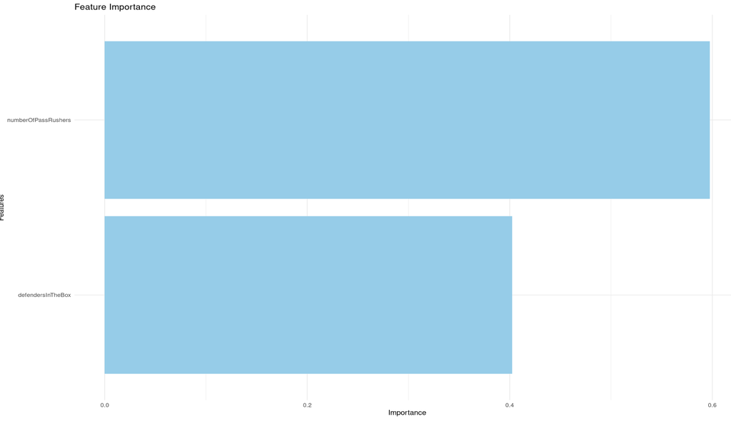

## Predicting EPA With Pre-snap Variables

```
-Variables used quarter, down, yards to go, offensive formation,
defenders in the box, and absolute yard number.
```

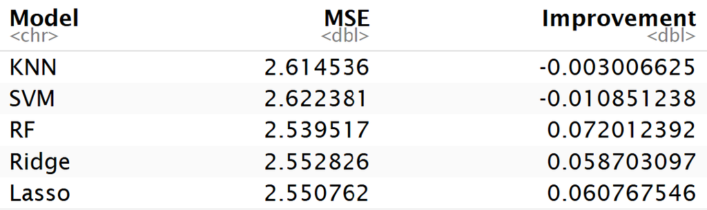

## References

The National Football League. 2021. NFL Big Data Bowl 2021. Retrieved Oct 29, 2024, from https://www.kaggle.com/competitions/nfl-big-data-bowl-2021/data

Kaplan, Andee. Statistical Learning, Class Notes. PDF File. 2024. https://dsci445-csu.github.io/notes/2_stat_learning/20240829_2_stat_learning.pdf

Kaplan, Andee. Regression, Class Notes. PDF File. 2024. https://dsci445-csu.github.io/notes/3_regression/20240910_3_regression.pdf

Kaplan, Andee. Classification, Class Notes. PDF File. 2024. https://dsci445-csu.github.io/notes/4_classification/20240919_4_classification.pdf